# Data Analysis and Visualization Bangalore Restaurants

## Data Analysis with Python using Bangalore Restaurent Data Set

Data analysis, and in essence helps us unlock the information and insights from raw data, to answer our questions. So data analysis plays an important role by helping us to discover useful information from data for further processing to the predicting the future for the unknown data

## Kaggle data set [URL](https://www.kaggle.com/himanshupoddar/zomato-bangalore-restaurants#zomato.csv)

### Columns description

1. url: contains the url of the restaurant in the zomato website
2. address: contains the address of the restaurant in Bengaluru
3. name: contains the name of the restaurant
4. online_order: whether online ordering is available in the restaurant or not
5. book_table: table book option available or not
6. rate: contains the overall rating of the restaurant out of 5
7. votes: contains total number of rating for the restaurant as of the above mentioned date
8. phone: contains the phone number of the restaurant
9. location: contains the neighborhood in which the restaurant is located
10. rest_type: restaurant type
11. dish_liked: dishes people liked in the restaurant
12. cuisines: food styles, separated by comma
13. approx_cost: (for two people)contains the approximate cost for meal for two people
14. reviews_list: list of tuples containing reviews for the restaurant, each tuple consists of two values, rating and review by the customer
15. menu_item: contains list of menus available in the restaurant
16. listed_in(type):type of meal
17. listed_in(city): contains the neighborhood in which the restaurant is listed

#### Importing the library

```python
import numpy as np
import pandas as pd
```

#### Load the dataset in pandas dataframe

```python
data_Frame=pd.read_csv("zomato.csv")
```

#### Understanding the data

```python
data_Frame
```

|  | url | address | name | online_order | book_table | rate | votes | phone | location | rest_type | dish_liked | cuisines | approx_cost(for two people) | reviews_list | menu_item | listed_in(type) | listed_in(city) |
| --- | --- | --- | --- | --- | --- | --- | --- | --- | --- | --- | --- | --- | --- | --- | --- | --- | --- |
| 0 | https://www.zomato.com/bangalore/jalsa-banasha... | 942, 21st Main Road, 2nd Stage, Banashankari, ... | Jalsa | Yes | Yes | 4.1/5 | 775 | 080 42297555\r\n+91 9743772233 | Banashankari | Casual Dining | Pasta, Lunch Buffet, Masala Papad, Paneer Laja... | North Indian, Mughlai, Chinese | 800 | [('Rated 4.0', 'RATED\n A beautiful place to ... | [] | Buffet | Banashankari |
| 1 | https://www.zomato.com/bangalore/spice-elephan... | 2nd Floor, 80 Feet Road, Near Big Bazaar, 6th ... | Spice Elephant | Yes | No | 4.1/5 | 787 | 080 41714161 | Banashankari | Casual Dining | Momos, Lunch Buffet, Chocolate Nirvana, Thai G... | Chinese, North Indian, Thai | 800 | [('Rated 4.0', 'RATED\n Had been here for din... | [] | Buffet | Banashankari |
| 2 | https://www.zomato.com/SanchurroBangalore?cont... | 1112, Next to KIMS Medical College, 17th Cross... | San Churro Cafe | Yes | No | 3.8/5 | 918 | +91 9663487993 | Banashankari | Cafe, Casual Dining | Churros, Cannelloni, Minestrone Soup, Hot Choc... | Cafe, Mexican, Italian | 800 | [('Rated 3.0', "RATED\n Ambience is not that ... | [] | Buffet | Banashankari |
| 3 | https://www.zomato.com/bangalore/addhuri-udupi... | 1st Floor, Annakuteera, 3rd Stage, Banashankar... | Addhuri Udupi Bhojana | No | No | 3.7/5 | 88 | +91 9620009302 | Banashankari | Quick Bites | Masala Dosa | South Indian, North Indian | 300 | [('Rated 4.0', "RATED\n Great food and proper... | [] | Buffet | Banashankari |
| 4 | https://www.zomato.com/bangalore/grand-village... | 10, 3rd Floor, Lakshmi Associates, Gandhi Baza... | Grand Village | No | No | 3.8/5 | 166 | +91 8026612447\r\n+91 9901210005 | Basavanagudi | Casual Dining | Panipuri, Gol Gappe | North Indian, Rajasthani | 600 | [('Rated 4.0', 'RATED\n Very good restaurant ... | [] | Buffet | Banashankari |
| 5 | https://www.zomato.com/bangalore/timepass-dinn... | 37, 5-1, 4th Floor, Bosco Court, Gandhi Bazaar... | Timepass Dinner | Yes | No | 3.8/5 | 286 | +91 9980040002\r\n+91 9980063005 | Basavanagudi | Casual Dining | Onion Rings, Pasta, Kadhai Paneer, Salads, Sal... | North Indian | 600 | [('Rated 3.0', 'RATED\n Food 3/5\nAmbience 3/... | [] | Buffet | Banashankari |
| 6 | https://www.zomato.com/bangalore/rosewood-inte... | 19/1, New Timberyard Layout, Beside Satellite ... | Rosewood International Hotel - Bar & Restaurant | No | No | 3.6/5 | 8 | +91 9731716688\r\n080 26740366 | Mysore Road | Casual Dining | NaN | North Indian, South Indian, Andhra, Chinese | 800 | [('Rated 5.0', 'RATED\n Awesome food ??Great ... | [] | Buffet | Banashankari |
| 7 | https://www.zomato.com/bangalore/onesta-banash... | 2469, 3rd Floor, 24th Cross, Opposite BDA Comp... | Onesta | Yes | Yes | 4.6/5 | 2556 | 080 48653961\r\n080 48655715 | Banashankari | Casual Dining, Cafe | Farmhouse Pizza, Chocolate Banana, Virgin Moji... | Pizza, Cafe, Italian | 600 | [('Rated 5.0', 'RATED\n I personally really l... | [] | Cafes | Banashankari |
| 8 | https://www.zomato.com/bangalore/penthouse-caf... | 1, 30th Main Road, 3rd Stage, Banashankari, Ba... | Penthouse Cafe | Yes | No | 4.0/5 | 324 | +91 8884135549\r\n+91 9449449316 | Banashankari | Cafe | Pizza, Mocktails, Coffee, Nachos, Salad, Pasta... | Cafe, Italian, Continental | 700 | [('Rated 3.0', "RATED\n I had been to this pl... | [] | Cafes | Banashankari |
| 9 | https://www.zomato.com/bangalore/smacznego-ban... | 2470, 21 Main Road, 25th Cross, Banashankari, ... | Smacznego | Yes | No | 4.2/5 | 504 | +91 9945230807\r\n+91 9743804471 | Banashankari | Cafe | Waffles, Pasta, Coleslaw Sandwich, Choco Waffl... | Cafe, Mexican, Italian, Momos, Beverages | 550 | [('Rated 4.0', "RATED\n Easy to locate\nVFM 3... | [] | Cafes | Banashankari |
| 10 | https://www.zomato.com/bangalore/caf%C3%A9-dow... | 12,29 Near PES University Back Gate, D'Souza N... | CafÃÂÃÂÃÂÃÂ© Down The A... | Yes | No | 4.1/5 | 402 | 080 26724489\r\n+91 7406048982 | Banashankari | Cafe | Waffles, Pasta, Crispy Chicken, Honey Chilli C... | Cafe | 500 | [('Rated 4.0', 'RATED\n We ended up here on a... | [] | Cafes | Banashankari |
| 11 | https://www.zomato.com/bangalore/cafe-shuffle-... | 941, 3rd FLOOR, 21st Main, 22nd Cross, Banasha... | Cafe Shuffle | Yes | Yes | 4.2/5 | 150 | +91 9742166777 | Banashankari | Cafe | Mocktails, Peri Fries, Lasagne, Pizza, Chicken... | Cafe, Italian, Continental | 600 | [('Rated 1.0', "RATED\n \n\nHorrible. Not even... | [] | Cafes | Banashankari |
| 12 | https://www.zomato.com/bangalore/the-coffee-sh... | 6th Block, 3rd Stage, Banashankari, Bangalore | The Coffee Shack | Yes | Yes | 4.2/5 | 164 | +91 9731644212 | Banashankari | Cafe | Coffee, Spaghetti, Pancakes, Nachos, Pasta, Sa... | Cafe, Chinese, Continental, Italian | 500 | [('Rated 4.0', "RATED\n Food - 4/5\nAmbience ... | [] | Cafes | Banashankari |
| 13 | https://www.zomato.com/bangalore/caf-eleven-ba... | 111, Sapphire Toys Building, 100 Feet Ring Roa... | Caf-Eleven | No | No | 4.0/5 | 424 | 080 49577715 | Banashankari | Cafe | Sandwich, Omelette, Ice Tea, Virgin Mojito, Ho... | Cafe, Continental | 450 | [('Rated 2.0', "RATED\n This is a hookah cafe... | [] | Cafes | Banashankari |
| 14 | https://www.zomato.com/SanchurroBangalore?cont... | 1112, Next to KIMS Medical College, 17th Cross... | San Churro Cafe | Yes | No | 3.8/5 | 918 | +91 9663487993 | Banashankari | Cafe, Casual Dining | Churros, Cannelloni, Minestrone Soup, Hot Choc... | Cafe, Mexican, Italian | 800 | [('Rated 3.0', "RATED\n Ambience is not that ... | [] | Cafes | Banashankari |
| 15 | https://www.zomato.com/bangalore/cafe-vivacity... | 2303, 21st Cross, K R Road, 2nd Stage, Banasha... | Cafe Vivacity | Yes | No | 3.8/5 | 90 | 080 26768182\r\n+91 9845704455 | Banashankari | Cafe | Garlic Bread, Burgers, Sandwiches, Pizza, Hot ... | Cafe | 650 | [('Rated 2.0', 'RATED\n Not so good place as ... | [] | Cafes | Banashankari |
| 16 | https://www.zomato.com/bangalore/catch-up-ino-... | 241, 4th Floor, 100 Feet Ring Road, Opposite K... | Catch-up-ino | Yes | No | 3.9/5 | 133 | +91 9972988038\r\n+91 9900121238 | Banashankari | Cafe | Momos, Mushroom Bruschettas, Jalapeno Cheeseba... | Cafe, Fast Food, Continental, Chinese, Momos | 800 | [('Rated 1.0', "RATED\n This place is right o... | [] | Cafes | Banashankari |
| 17 | https://www.zomato.com/bangalore/kirthis-birya... | 405, 24th Cross, 9th Main, 2nd Stage, Banashan... | Kirthi's Biryani | Yes | No | 3.8/5 | 144 | 080 26711554\r\n+91 9741406338 | Banashankari | Cafe | Pasta, Gelato, Garlic Bread, Mojito, Nachos, P... | Chinese, Cafe, Italian | 700 | [('Rated 3.0', "RATED\n New place.. though it... | [] | Cafes | Banashankari |
| 18 | https://www.zomato.com/bangalore/t3h-cafe-bana... | 504, CJ Venkata Das Road, Padmanabhangar, 2nd ... | T3H Cafe | No | No | 3.9/5 | 93 | +91 8884726600 | Banashankari | Cafe | Cheese Maggi, Peri Peri Fries, Pasta Arrabiata | Cafe, Italian, American | 300 | [('Rated 4.0', "RATED\n Happy to see such a c... | [] | Cafes | Banashankari |
| 19 | https://www.zomato.com/bangalore/360-atoms-res... | 47, 48 &49, 3Rd Floor, 21st Main Road, 2nd Sta... | 360 Atoms Restaurant And Cafe | Yes | No | 3.1/5 | 13 | +91 9880594520 | Banashankari | Cafe | NaN | Cafe, Chinese, Continental, Italian | 400 | [('Rated 5.0', 'RATED\n Friendly staffs , nic... | [] | Cafes | Banashankari |
| 20 | https://www.zomato.com/bangalore/the-vintage-c... | 146, 50 ft Road, 3rd Phase, 3rd Stage, Near Ka... | The Vintage Cafe | Yes | No | 3.0/5 | 62 | +91 9880016665\r\n+91 8217311687 | Banashankari | Cafe | Burgers, Caramel Milkshake, Iced Coffee, Iced Tea | Cafe, French, North Indian | 400 | [('Rated 2.0', "RATED\n This is a tiny cafÃ\... | [] | Cafes | Banashankari |
| 21 | https://www.zomato.com/bangalore/woodee-pizza-... | 3353, 2nd Cross, Opposite Auden School, Hosker... | Woodee Pizza | Yes | No | 3.7/5 | 180 | +91 7406822844 | Banashankari | Cafe | Pizza, Garlic Bread | Cafe, Pizza, Fast Food, Beverages | 500 | [('Rated 3.0', 'RATED\n Decided to take a bre... | [] | Cafes | Banashankari |
| 22 | https://www.zomato.com/bangalore/cafe-coffee-d... | SRF Complex, Near BDA Complex, Kathreguppe Mai... | Cafe Coffee Day | No | No | 3.6/5 | 28 | 080 32486296 | Banashankari | Cafe | NaN | Cafe, Fast Food | 900 | [('Rated 4.0', 'RATED\n This outlet is better... | [] | Cafes | Banashankari |
| 23 | https://www.zomato.com/bangalore/my-tea-house-... | 224/Y, 4th Phase, 7th Block, 100 Feet Ring Roa... | My Tea House | Yes | No | 3.6/5 | 62 | 080 65975430\r\n+91 7337733798 | Banashankari | Quick Bites, Cafe | Pasta, Iced Tea | Italian, Fast Food, Cafe, European | 600 | [('Rated 4.0', "RATED\n So, went here with fr... | [] | Cafes | Banashankari |
| 24 | https://www.zomato.com/bangalore/hide-out-cafe... | 775/1, Opposite Gupta Collage, 7th Block, 3rd ... | Hide Out Cafe | No | No | 3.7/5 | 31 | +91 9901481185 | Banashankari | Cafe | NaN | Cafe | 300 | [('Rated 4.0', 'RATED\n The food was quite go... | [] | Cafes | Banashankari |
| 25 | https://www.zomato.com/bangalore/cafe-nova-ban... | 101, Water Tank Road, 2nd Block, 3rd Stage, Ba... | CAFE NOVA | No | No | 3.2/5 | 11 | +91 8971090261 | Banashankari | Cafe | NaN | Cafe, Bakery | 600 | [('Rated 1.0', "RATED\n No ventilation. Smoke... | [] | Cafes | Banashankari |
| 26 | https://www.zomato.com/bangalore/coffee-tindi-... | 27th Cross Rd, Banashankari Stage II, Banashan... | Coffee Tindi | Yes | No | 3.8/5 | 75 | +91 9945758046 | Banashankari | Cafe, Quick Bites | NaN | Cafe, South Indian | 200 | [('Rated 5.0', 'RATED\n please provide some e... | [] | Cafes | Banashankari |
| 27 | https://www.zomato.com/bangalore/sea-green-caf... | 1036, Srinidhi Plaza, 3rd floor, Above Nilgiri... | Sea Green Cafe | No | No | 3.3/5 | 4 | +91 9008628448 | Banashankari | Cafe | NaN | Cafe, Fast Food, Beverages | 500 | [('Rated 5.0', 'RATED\n Newly opened cafe nea... | [] | Cafes | Banashankari |
| 28 | https://www.zomato.com/bangalore/cuppa-1-banas... | 940, Shantha Complex, 20th Main, 2nd Stage, Ba... | Cuppa | No | No | 3.3/5 | 23 | +91 9591111123 | Banashankari | Cafe | NaN | Cafe, Fast Food | 550 | [('Rated 1.5', 'RATED\n This place was good t... | [] | Cafes | Banashankari |
| 29 | https://www.zomato.com/bangalore/srinathjis-ca... | 112, Bull Temple Road,next to more Basavanagud... | Srinathji's Cafe | No | No | 3.8/5 | 148 | 080 26600704\r\n+91 9342593424 | Basavanagudi | Casual Dining, Cafe | Paratha, Sandwich, Chilli Idli, Noodles, Sandw... | North Indian, Cafe, Chinese, Fast Food | 550 | [('Rated 5.0', 'RATED\n No words for the pane... | [] | Cafes | Banashankari |
| ... | ... | ... | ... | ... | ... | ... | ... | ... | ... | ... | ... | ... | ... | ... | ... | ... | ... |
| 51687 | https://www.zomato.com/bangalore/red-rhino-whi... | 4th Floor, Uptown Square, Seegehalli, Near All... | Red Rhino | Yes | Yes | 4.4 /5 | 1980 | 080 49652108 | Whitefield | Microbrewery, Pub | Beer, Margarita, Long Island Iced Tea, Cocktai... | Continental, Mediterranean, South Indian, Nort... | 1,700 | [('Rated 4.0', 'RATED\n Red Rhino is a Brewer... | ['Hangover', 'Smoking Hot Red Rhino Chilli Chi... | Pubs and bars | Whitefield |
| 51688 | https://www.zomato.com/bangalore/ji-hazoor-whi... | TR 9, 4th Floor, Plot 95, EPIP Zone, Near Vaid... | Ji Hazoor | Yes | Yes | 4.0 /5 | 2856 | 080 49652519 | Whitefield | Casual Dining, Bar | Chicken Salad, Mocktails, Mutton Curry, Chicke... | Mughlai, North Indian, Biryani, Afghan | 1,100 | [('Rated 4.0', 'RATED\n Was there on last Wed... | ['Dal Tadka', 'Dal Makhani', 'Paneer Tikka Mas... | Pubs and bars | Whitefield |
| 51689 | https://www.zomato.com/bangalore/hq-whitefield... | 75, Inorbit Mall, EPIP Area, Road 7, Whitefiel... | HQ | No | Yes | 4.1 /5 | 564 | +91 9945577195\n+91 9886144774 | Whitefield | Casual Dining, Bar | Mocktails, Pizza, Crispy Chicken, Beer, Nachos... | North Indian, Italian, Finger Food, Continental | 1,000 | [('Rated 3.0', "RATED\n HQ is located at grou... | [] | Pubs and bars | Whitefield |
| 51690 | https://www.zomato.com/bangalore/biere-societe... | 223-1, ITPL Main Road, Sadarmangala, KR Puram ... | Biere Societee | No | Yes | 4.2 /5 | 320 | +91 8296412555\n080 28413555 | Whitefield | Pub | Tempura Prawns, Cocktails, Noodles, Masala Pea... | Asian, Continental, European | 1,500 | [('Rated 3.0', 'RATED\n Went with Team on Thu... | [] | Pubs and bars | Whitefield |
| 51691 | https://www.zomato.com/bangalore/uno-chicago-b... | Shop FB-02, Upper Ground Floor, Prestige Shant... | Uno Chicago Bar & Grill | No | Yes | 4.2 /5 | 156 | +91 9667540036\n+91 7042349751 | Whitefield | Bar, Casual Dining | Deep Dish Pizza, Mocktails, Burgers, Onion Rin... | American, Italian | 1,800 | [('Rated 4.0', "RATED\n Had been here for lun... | [] | Pubs and bars | Whitefield |
| 51692 | https://www.zomato.com/bangalore/amoeba-sports... | Third Floor, Ascendas Park Square, ITPL Main R... | Amoeba Sports Bar | Yes | Yes | 3.9 /5 | 578 | +91 9845555740\n+91 9886743857 | Whitefield | Lounge, Bar | Pasta, Fish, Beer, Chicken Wings, Mocktails, G... | Continental, Chinese | 1,000 | [('Rated 3.0', 'RATED\n Amoeba is affordable ... | [] | Pubs and bars | Whitefield |
| 51693 | https://www.zomato.com/bangalore/one-for-the-r... | 87/2A & 87/3, SH 35, Seegehalli, Whitefield, B... | One For The Road | Yes | Yes | 4.1 /5 | 137 | 080 49652780 | Whitefield | Bar | Cocktails, Pasta, Fish | Continental, North Indian, Finger Food | 1,200 | [('Rated 4.0', 'RATED\n Had been there on a S... | ['Chicken Manchow Soup', 'Chicken Lollipop', '... | Pubs and bars | Whitefield |
| 51694 | https://www.zomato.com/WhitefieldSocial?contex... | 29, Ground Floor, Phoenix Market City, Whitefi... | Whitefield Social | Yes | No | 4.1 /5 | 2773 | +91 8049626661\n+91 9886252234 | Whitefield | Pub | Cocktails, Chicken Kebab, Murgh Ghee Roast, Vi... | American, North Indian, Chinese, Finger Food, ... | 1,500 | [('Rated 2.0', 'RATED\n Honestly speaking it ... | ['Chilli Paneer Black Pepper China Box', 'Chil... | Pubs and bars | Whitefield |
| 51695 | https://www.zomato.com/bangalore/the-whitefiel... | The Waverly Hotels, Whitefield, Bangalore | The Whitefield Arms Pub & Microbrewery | Yes | Yes | 4.2 /5 | 1113 | 080 49653340 | Whitefield | Pub, Microbrewery | Beer, Chicken Tikka, Cosmopolitan, Burgers, Co... | British, Continental, BBQ | 1,600 | [('Rated 4.0', "RATED\n I never knew of this ... | [] | Pubs and bars | Whitefield |
| 51696 | https://www.zomato.com/bangalore/the-irish-hou... | TF-01A, Level 3, VR Mall, Mahadevpura, Whitefi... | The Irish House | No | Yes | 4.3 /5 | 1776 | +91 8317403477\n+91 9886634664 | Whitefield | Casual Dining, Pub | Beer, Cocktails, Burgers, Chicken Nachos, Mock... | European, American | 1,700 | [('Rated 4.0', 'RATED\n Nice place to grab a ... | [] | Pubs and bars | Whitefield |
| 51697 | https://www.zomato.com/bangalore/shizusan-shop... | Level 2, Phoenix Marketcity, Mahadevpura, Whit... | Shizusan Shophouse & Bar | Yes | Yes | 4.4 /5 | 1313 | 080 67266655\n080 49626655 | Whitefield | Casual Dining, Bar | California Roll, Cocktails, Mocktails, Maki Ro... | Asian, Japanese, Vietnamese, Korean, Chinese, ... | 1,800 | [('Rated 3.0', 'RATED\n Wanted to try this pl... | [] | Pubs and bars | Whitefield |
| 51698 | https://www.zomato.com/bangalore/kava-kitchen-... | 3-A1, Kundanahalli Main Road, Mahadevpura, Opp... | Kava Kitchen & Bar - Fairfield by Marriott | No | No | 3.9 /5 | 74 | 080 68141414 | Whitefield | Casual Dining, Bar | Dal Halwa | North Indian, South Indian, Continental, Ameri... | 1,200 | [('Rated 4.0', 'RATED\n Loved the food, thoug... | [] | Pubs and bars | Whitefield |
| 51699 | https://www.zomato.com/bangalore/harrys-bar-ca... | S-10, Level 2, Phoenix Market City, Whitefield... | Harry's Bar + Cafe | Yes | Yes | 4.1 /5 | 1218 | +91 7676924054\n+91 9137153744 | Whitefield | Pub | Cocktails, Beer, Long Island Iced Tea, Pasta, ... | Asian, American, Mexican | 1,200 | [('Rated 4.0', 'RATED\n The first thing that ... | [] | Pubs and bars | Whitefield |
| 51700 | https://www.zomato.com/bangalore/bar-bar-white... | Level 2, Phoenix Marketcity, Whitefield, Banga... | BAR BAR | No | Yes | 4.1 /5 | 1003 | +91 7338630404\n+91 8067266651 | Whitefield | Bar, Casual Dining | Mocktails, Cocktails, Pizza, Chicken Tikka, Na... | Continental, North Indian, Italian | 1,500 | [('Rated 4.0', "RATED\n In an increasingly ov... | [] | Pubs and bars | Whitefield |
| 51701 | https://www.zomato.com/bangalore/the-beer-cafe... | Unit 4A - 4B, Upper Ground Floor, VR Bengaluru... | The Beer Cafe | Yes | Yes | 4.1 /5 | 673 | +91 8929188573 | Whitefield | Pub | Cocktails, Wheat Beer, Bruschettas, Pasta, Bur... | Finger Food, North Indian, Chinese, Italian | 1,400 | [('Rated 2.0', "RATED\n We went out to this p... | [] | Pubs and bars | Whitefield |
| 51702 | https://www.zomato.com/bangalore/pablos-gastro... | 2, Graphite India Road, Doddanekundi Industria... | Pablo's Gastrobar | No | No | 4.0 /5 | 1094 | 00 9108214702 | Whitefield | Bar | Cocktails, Beer, Pizza, Long Island Iced Tea, ... | Finger Food, American, Asian, Italian | 1,450 | [('Rated 4.0', 'RATED\n A good place to dine.... | [] | Pubs and bars | Whitefield |
| 51703 | https://www.zomato.com/bangalore/olivers-pub-d... | ITPL Ascendas Park Square Mall, ITPL, First Fl... | Oliver's Pub & Diner | Yes | Yes | 3.9 /5 | 548 | +91 8043691111\n+91 8028026519 | Whitefield | Pub, Casual Dining | Pizza, Beer, Cocktails, Nachos, Pasta, Moo Bur... | Finger Food, American, Continental, Burger, Pizza | 1,500 | [('Rated 4.0', "RATED\n I had :-\n\n1. Italia... | [] | Pubs and bars | Whitefield |
| 51704 | https://www.zomato.com/bangalore/smaaash-white... | 2nd Floor, Phoenix Market City, Whitefield, Ba... | Smaaash | No | Yes | 4.0 /5 | 189 | +91 9900069474\n+91 7899644468 | Whitefield | Casual Dining, Pub | Pizza, Beer | North Indian, Pizza, Chinese | 1,500 | [('Rated 3.0', 'RATED\n Like this place for z... | [] | Pubs and bars | Whitefield |
| 51705 | https://www.zomato.com/bangalore/izakaya-gastr... | 2nd Floor, Iona, Virginia Mall, Whitefield Mai... | Izakaya Gastro Pub | Yes | Yes | 3.8 /5 | 128 | +91 7625087121\n+91 8050587483 | Whitefield | Bar, Casual Dining | Beer, Chicken Guntur, Paneer Tikka, Fish, Nood... | North Indian, Continental, Mediterranean | 1,200 | [('Rated 3.0', "RATED\n Nice place to hangout... | [] | Pubs and bars | Whitefield |
| 51706 | https://www.zomato.com/bangalore/red-glow-whit... | Poornima Complex, Dodsworth Layout, Whitefield... | Red Glow | No | No | 3.7 /5 | 27 | +91 9740571131 | Whitefield | Pub | NaN | North Indian, Continental | 1,200 | [('Rated 5.0', 'RATED\n Excellent place had n... | [] | Pubs and bars | Whitefield |
| 51707 | https://www.zomato.com/bangalore/m-bar-bengalu... | Bengaluru Marriott Hotel, 75, 8th Road, EPIP A... | M Bar - Bengaluru Marriott Hotel Whitefield | No | No | 3.9 /5 | 77 | 080 49435000 | Whitefield | Fine Dining, Bar | Rooftop Ambience | Finger Food | 2,000 | [('Rated 4.0', 'RATED\n Went there post dinne... | [] | Pubs and bars | Whitefield |
| 51708 | https://www.zomato.com/bangalore/keys-cafe-key... | Keys Hotel, 6, 1st Phase Industrial Area, Near... | Keys Cafe - Keys Hotel | No | No | 2.8 /5 | 161 | 080 39451000\n+91 8884038484 | Whitefield | Casual Dining, Bar | Salads, Coffee, Breakfast Buffet, Halwa, Chick... | Chinese, Continental, North Indian | 1,200 | [('Rated 3.0', 'RATED\n Place is good not tha... | [] | Pubs and bars | Whitefield |
| 51709 | https://www.zomato.com/bangalore/the-farm-hous... | 136, SAP Labs India, KIADB Export Promotion In... | The Farm House Bar n Grill | No | No | 3.7 /5 | 34 | +91 9980121279\n+91 9900240646 | Whitefield | Casual Dining, Bar | NaN | North Indian, Continental | 800 | [('Rated 4.0', 'RATED\n Ambience- Big and spa... | [] | Pubs and bars | Whitefield |
| 51710 | https://www.zomato.com/bangalore/topsy-turvey-... | 2E2, 4th Cross Road, Devasandra Industrial Est... | Topsy Turvey | No | No | NaN | 0 | +91 9148155994 | Whitefield | Bar | NaN | Finger Food | 900 | [('Rated 4.0', "RATED\n A divine joint for Fl... | [] | Pubs and bars | Whitefield |
| 51711 | https://www.zomato.com/bangalore/bhagini-2-whi... | 139/C1, Next To GR Tech Park, Pattandur Agraha... | Bhagini | No | No | 2.5 /5 | 81 | 080 65951222 | Whitefield | Casual Dining, Bar | Biryani, Andhra Meal | Andhra, South Indian, Chinese, North Indian | 800 | [('Rated 4.0', 'RATED\n A fine place to chill... | [] | Pubs and bars | Whitefield |
| 51712 | https://www.zomato.com/bangalore/best-brews-fo... | Four Points by Sheraton Bengaluru, 43/3, White... | Best Brews - Four Points by Sheraton Bengaluru... | No | No | 3.6 /5 | 27 | 080 40301477 | Whitefield | Bar | NaN | Continental | 1,500 | [('Rated 5.0', "RATED\n Food and service are ... | [] | Pubs and bars | Whitefield |
| 51713 | https://www.zomato.com/bangalore/vinod-bar-and... | Number 10, Garudachar Palya, Mahadevapura, Whi... | Vinod Bar And Restaurant | No | No | NaN | 0 | +91 8197675843 | Whitefield | Bar | NaN | Finger Food | 600 | [] | [] | Pubs and bars | Whitefield |
| 51714 | https://www.zomato.com/bangalore/plunge-sherat... | Sheraton Grand Bengaluru Whitefield Hotel & Co... | Plunge - Sheraton Grand Bengaluru Whitefield H... | No | No | NaN | 0 | NaN | Whitefield | Bar | NaN | Finger Food | 2,000 | [] | [] | Pubs and bars | Whitefield |
| 51715 | https://www.zomato.com/bangalore/chime-sherato... | Sheraton Grand Bengaluru Whitefield Hotel & Co... | Chime - Sheraton Grand Bengaluru Whitefield Ho... | No | Yes | 4.3 /5 | 236 | 080 49652769 | ITPL Main Road, Whitefield | Bar | Cocktails, Pizza, Buttermilk | Finger Food | 2,500 | [('Rated 4.0', 'RATED\n Nice and friendly pla... | [] | Pubs and bars | Whitefield |
| 51716 | https://www.zomato.com/bangalore/the-nest-the-... | ITPL Main Road, KIADB Export Promotion Industr... | The Nest - The Den Bengaluru | No | No | 3.4 /5 | 13 | +91 8071117272 | ITPL Main Road, Whitefield | Bar, Casual Dining | NaN | Finger Food, North Indian, Continental | 1,500 | [('Rated 5.0', 'RATED\n Great ambience , look... | [] | Pubs and bars | Whitefield |

51717 rows × 17 columns

#### As we can see above data set is very difficult to analyse so we will use just check 10 row of data for analysis using head() function in pandas data frame top 5 data and tail() function for bottom 5 data

```python
data_Frame.head()
```

|  | url | address | name | online_order | book_table | rate | votes | phone | location | rest_type | dish_liked | cuisines | approx_cost(for two people) | reviews_list | menu_item | listed_in(type) | listed_in(city) |
| --- | --- | --- | --- | --- | --- | --- | --- | --- | --- | --- | --- | --- | --- | --- | --- | --- | --- |
| 0 | https://www.zomato.com/bangalore/jalsa-banasha... | 942, 21st Main Road, 2nd Stage, Banashankari, ... | Jalsa | Yes | Yes | 4.1/5 | 775 | 080 42297555\r\n+91 9743772233 | Banashankari | Casual Dining | Pasta, Lunch Buffet, Masala Papad, Paneer Laja... | North Indian, Mughlai, Chinese | 800 | [('Rated 4.0', 'RATED\n A beautiful place to ... | [] | Buffet | Banashankari |
| 1 | https://www.zomato.com/bangalore/spice-elephan... | 2nd Floor, 80 Feet Road, Near Big Bazaar, 6th ... | Spice Elephant | Yes | No | 4.1/5 | 787 | 080 41714161 | Banashankari | Casual Dining | Momos, Lunch Buffet, Chocolate Nirvana, Thai G... | Chinese, North Indian, Thai | 800 | [('Rated 4.0', 'RATED\n Had been here for din... | [] | Buffet | Banashankari |
| 2 | https://www.zomato.com/SanchurroBangalore?cont... | 1112, Next to KIMS Medical College, 17th Cross... | San Churro Cafe | Yes | No | 3.8/5 | 918 | +91 9663487993 | Banashankari | Cafe, Casual Dining | Churros, Cannelloni, Minestrone Soup, Hot Choc... | Cafe, Mexican, Italian | 800 | [('Rated 3.0', "RATED\n Ambience is not that ... | [] | Buffet | Banashankari |
| 3 | https://www.zomato.com/bangalore/addhuri-udupi... | 1st Floor, Annakuteera, 3rd Stage, Banashankar... | Addhuri Udupi Bhojana | No | No | 3.7/5 | 88 | +91 9620009302 | Banashankari | Quick Bites | Masala Dosa | South Indian, North Indian | 300 | [('Rated 4.0', "RATED\n Great food and proper... | [] | Buffet | Banashankari |
| 4 | https://www.zomato.com/bangalore/grand-village... | 10, 3rd Floor, Lakshmi Associates, Gandhi Baza... | Grand Village | No | No | 3.8/5 | 166 | +91 8026612447\r\n+91 9901210005 | Basavanagudi | Casual Dining | Panipuri, Gol Gappe | North Indian, Rajasthani | 600 | [('Rated 4.0', 'RATED\n Very good restaurant ... | [] | Buffet | Banashankari |

```python
data_Frame.tail()
```

|  | url | address | name | online_order | book_table | rate | votes | phone | location | rest_type | dish_liked | cuisines | approx_cost(for two people) | reviews_list | menu_item | listed_in(type) | listed_in(city) |
| --- | --- | --- | --- | --- | --- | --- | --- | --- | --- | --- | --- | --- | --- | --- | --- | --- | --- |
| 51712 | https://www.zomato.com/bangalore/best-brews-fo... | Four Points by Sheraton Bengaluru, 43/3, White... | Best Brews - Four Points by Sheraton Bengaluru... | No | No | 3.6 /5 | 27 | 080 40301477 | Whitefield | Bar | NaN | Continental | 1,500 | [('Rated 5.0', "RATED\n Food and service are ... | [] | Pubs and bars | Whitefield |
| 51713 | https://www.zomato.com/bangalore/vinod-bar-and... | Number 10, Garudachar Palya, Mahadevapura, Whi... | Vinod Bar And Restaurant | No | No | NaN | 0 | +91 8197675843 | Whitefield | Bar | NaN | Finger Food | 600 | [] | [] | Pubs and bars | Whitefield |
| 51714 | https://www.zomato.com/bangalore/plunge-sherat... | Sheraton Grand Bengaluru Whitefield Hotel & Co... | Plunge - Sheraton Grand Bengaluru Whitefield H... | No | No | NaN | 0 | NaN | Whitefield | Bar | NaN | Finger Food | 2,000 | [] | [] | Pubs and bars | Whitefield |
| 51715 | https://www.zomato.com/bangalore/chime-sherato... | Sheraton Grand Bengaluru Whitefield Hotel & Co... | Chime - Sheraton Grand Bengaluru Whitefield Ho... | No | Yes | 4.3 /5 | 236 | 080 49652769 | ITPL Main Road, Whitefield | Bar | Cocktails, Pizza, Buttermilk | Finger Food | 2,500 | [('Rated 4.0', 'RATED\n Nice and friendly pla... | [] | Pubs and bars | Whitefield |
| 51716 | https://www.zomato.com/bangalore/the-nest-the-... | ITPL Main Road, KIADB Export Promotion Industr... | The Nest - The Den Bengaluru | No | No | 3.4 /5 | 13 | +91 8071117272 | ITPL Main Road, Whitefield | Bar, Casual Dining | NaN | Finger Food, North Indian, Continental | 1,500 | [('Rated 5.0', 'RATED\n Great ambience , look... | [] | Pubs and bars | Whitefield |

#### Pandas library has function called info() which will give us column name and data type

the main types stored in Pandas dataframes are **object**, **float**, **int**, **bool** and **datetime64**. In order to better learn about each attribute, it is always good for us to know the data type of each column

```python
data_Frame.info()
```

```
<class 'pandas.core.frame.DataFrame'>
RangeIndex: 51717 entries, 0 to 51716
Data columns (total 17 columns):
url                            51717 non-null object
address                        51717 non-null object
name                           51717 non-null object
online_order                   51717 non-null object
book_table                     51717 non-null object
rate                           43942 non-null object
votes                          51717 non-null int64
phone                          50509 non-null object
location                       51696 non-null object
rest_type                      51490 non-null object
dish_liked                     23639 non-null object
cuisines                       51672 non-null object
approx_cost(for two people)    51371 non-null object
reviews_list                   51717 non-null object
menu_item                      51717 non-null object
listed_in(type)                51717 non-null object
listed_in(city)                51717 non-null object
dtypes: int64(1), object(16)
memory usage: 6.7+ MB
```

```python
data_Frame.dtypes
```

```
url                            object
address                        object
name                           object
online_order                   object
book_table                     object
rate                           object
votes                           int64
phone                          object
location                       object
rest_type                      object
dish_liked                     object
cuisines                       object
approx_cost(for two people)    object
reviews_list                   object
menu_item                      object
listed_in(type)                object
listed_in(city)                object
dtype: object
```

#### If we would like to get a statistical summary of each column, such as count, column mean value, column standard deviation, etc. We use the describe method: describe()

```python
data_Frame.describe()
```

|  | votes |
| --- | --- |
| count | 51717.000000 |
| mean | 283.697527 |
| std | 803.838853 |
| min | 0.000000 |
| 25% | 7.000000 |
| 50% | 41.000000 |
| 75% | 198.000000 |
| max | 16832.000000 |

#### Above describe function will always give us numerical data over view , it will not give us result for object data type

#### For getting all the datail vie we need to insert the paramenter as arguments include="all"

```python
data_Frame.describe(include="all")
```

|  | url | address | name | online_order | book_table | rate | votes | phone | location | rest_type | dish_liked | cuisines | approx_cost(for two people) | reviews_list | menu_item | listed_in(type) | listed_in(city) |
| --- | --- | --- | --- | --- | --- | --- | --- | --- | --- | --- | --- | --- | --- | --- | --- | --- | --- |
| count | 51717 | 51717 | 51717 | 51717 | 51717 | 43942 | 51717.000000 | 50509 | 51696 | 51490 | 23639 | 51672 | 51371 | 51717 | 51717 | 51717 | 51717 |
| unique | 51717 | 11495 | 8792 | 2 | 2 | 64 | NaN | 14926 | 93 | 93 | 5271 | 2723 | 70 | 22513 | 9098 | 7 | 30 |
| top | https://www.zomato.com/bangalore/sree-lakshmi-... | Delivery Only | Cafe Coffee Day | Yes | No | NEW | NaN | 080 43334321 | BTM | Quick Bites | Biryani | North Indian | 300 | [] | [] | Delivery | BTM |
| freq | 1 | 128 | 96 | 30444 | 45268 | 2208 | NaN | 216 | 5124 | 19132 | 182 | 2913 | 7576 | 7595 | 39617 | 25942 | 3279 |
| mean | NaN | NaN | NaN | NaN | NaN | NaN | 283.697527 | NaN | NaN | NaN | NaN | NaN | NaN | NaN | NaN | NaN | NaN |
| std | NaN | NaN | NaN | NaN | NaN | NaN | 803.838853 | NaN | NaN | NaN | NaN | NaN | NaN | NaN | NaN | NaN | NaN |
| min | NaN | NaN | NaN | NaN | NaN | NaN | 0.000000 | NaN | NaN | NaN | NaN | NaN | NaN | NaN | NaN | NaN | NaN |
| 25% | NaN | NaN | NaN | NaN | NaN | NaN | 7.000000 | NaN | NaN | NaN | NaN | NaN | NaN | NaN | NaN | NaN | NaN |
| 50% | NaN | NaN | NaN | NaN | NaN | NaN | 41.000000 | NaN | NaN | NaN | NaN | NaN | NaN | NaN | NaN | NaN | NaN |
| 75% | NaN | NaN | NaN | NaN | NaN | NaN | 198.000000 | NaN | NaN | NaN | NaN | NaN | NaN | NaN | NaN | NaN | NaN |
| max | NaN | NaN | NaN | NaN | NaN | NaN | 16832.000000 | NaN | NaN | NaN | NaN | NaN | NaN | NaN | NaN | NaN | NaN |

#### by seeing above representation we can say that we have lot of missing value in the dataset

#### Get the null value in the dataset by there count

```python
data_Frame.isnull().sum()
```

```
url                                0
address                            0
name                               0
online_order                       0
book_table                         0
rate                            7775
votes                              0
phone                           1208
location                          21
rest_type                        227
dish_liked                     28078
cuisines                          45
approx_cost(for two people)      346
reviews_list                       0
menu_item                          0
listed_in(type)                    0
listed_in(city)                    0
dtype: int64
```

#### Rename some of the list features

```python
data_Frame = data_Frame.rename(columns = {"approx_cost(for two people)" : "avg_cost_of_2", "listed_in(type)" : "type_of_meal", "listed_in(city)" : "city"})
```

```python
data_Frame.head(2)
```

|  | url | address | name | online_order | book_table | rate | votes | phone | location | rest_type | dish_liked | cuisines | avg_cost_of_2 | reviews_list | menu_item | type_of_meal | city |
| --- | --- | --- | --- | --- | --- | --- | --- | --- | --- | --- | --- | --- | --- | --- | --- | --- | --- |
| 0 | https://www.zomato.com/bangalore/jalsa-banasha... | 942, 21st Main Road, 2nd Stage, Banashankari, ... | Jalsa | Yes | Yes | 4.1/5 | 775 | 080 42297555\r\n+91 9743772233 | Banashankari | Casual Dining | Pasta, Lunch Buffet, Masala Papad, Paneer Laja... | North Indian, Mughlai, Chinese | 800 | [('Rated 4.0', 'RATED\n A beautiful place to ... | [] | Buffet | Banashankari |
| 1 | https://www.zomato.com/bangalore/spice-elephan... | 2nd Floor, 80 Feet Road, Near Big Bazaar, 6th ... | Spice Elephant | Yes | No | 4.1/5 | 787 | 080 41714161 | Banashankari | Casual Dining | Momos, Lunch Buffet, Chocolate Nirvana, Thai G... | Chinese, North Indian, Thai | 800 | [('Rated 4.0', 'RATED\n Had been here for din... | [] | Buffet | Banashankari |

#### Select the important features to analysis

```python
selected_Columns=["name","online_order","book_table","rate","votes","rest_type","dish_liked","cuisines","avg_cost_of_2","reviews_list","type_of_meal","city"]
```

## Data Wrangling

1. Delete un-necessary feature Dealing with missing value
2. Data Formating and preprocessing
3. Data Normalizations
4. Binning
5. Turning Categorical variable into quantative variable

```python
df_Annalysis=data_Frame[selected_Columns]
```

```python
df_Annalysis.head(3)
```

|  | name | online_order | book_table | rate | votes | rest_type | dish_liked | cuisines | avg_cost_of_2 | reviews_list | type_of_meal | city |
| --- | --- | --- | --- | --- | --- | --- | --- | --- | --- | --- | --- | --- |
| 0 | Jalsa | Yes | Yes | 4.1/5 | 775 | Casual Dining | Pasta, Lunch Buffet, Masala Papad, Paneer Laja... | North Indian, Mughlai, Chinese | 800 | [('Rated 4.0', 'RATED\n A beautiful place to ... | Buffet | Banashankari |
| 1 | Spice Elephant | Yes | No | 4.1/5 | 787 | Casual Dining | Momos, Lunch Buffet, Chocolate Nirvana, Thai G... | Chinese, North Indian, Thai | 800 | [('Rated 4.0', 'RATED\n Had been here for din... | Buffet | Banashankari |
| 2 | San Churro Cafe | Yes | No | 3.8/5 | 918 | Cafe, Casual Dining | Churros, Cannelloni, Minestrone Soup, Hot Choc... | Cafe, Mexican, Italian | 800 | [('Rated 3.0', "RATED\n Ambience is not that ... | Buffet | Banashankari |

```python
df_Annalysis["rate"]=df_Annalysis["rate"].apply(lambda x: str(x).split('/')[0])
```

```python
df_Annalysis.head()
```

|  | name | online_order | book_table | rate | votes | rest_type | dish_liked | cuisines | avg_cost_of_2 | reviews_list | type_of_meal | city |
| --- | --- | --- | --- | --- | --- | --- | --- | --- | --- | --- | --- | --- |
| 0 | Jalsa | Yes | Yes | 4.1 | 775 | Casual Dining | Pasta, Lunch Buffet, Masala Papad, Paneer Laja... | North Indian, Mughlai, Chinese | 800 | [('Rated 4.0', 'RATED\n A beautiful place to ... | Buffet | Banashankari |
| 1 | Spice Elephant | Yes | No | 4.1 | 787 | Casual Dining | Momos, Lunch Buffet, Chocolate Nirvana, Thai G... | Chinese, North Indian, Thai | 800 | [('Rated 4.0', 'RATED\n Had been here for din... | Buffet | Banashankari |
| 2 | San Churro Cafe | Yes | No | 3.8 | 918 | Cafe, Casual Dining | Churros, Cannelloni, Minestrone Soup, Hot Choc... | Cafe, Mexican, Italian | 800 | [('Rated 3.0', "RATED\n Ambience is not that ... | Buffet | Banashankari |
| 3 | Addhuri Udupi Bhojana | No | No | 3.7 | 88 | Quick Bites | Masala Dosa | South Indian, North Indian | 300 | [('Rated 4.0', "RATED\n Great food and proper... | Buffet | Banashankari |
| 4 | Grand Village | No | No | 3.8 | 166 | Casual Dining | Panipuri, Gol Gappe | North Indian, Rajasthani | 600 | [('Rated 4.0', 'RATED\n Very good restaurant ... | Buffet | Banashankari |

```python
df_Annalysis.name.value_counts().head(20)
```

```
Cafe Coffee Day      96
Onesta               85
Just Bake            73
Empire Restaurant    71
Five Star Chicken    70
Kanti Sweets         68
Petoo                66
Polar Bear           65
Baskin Robbins       64
Chef Baker's         62
Pizza Hut            62
Domino's Pizza       60
Sweet Truth          60
Beijing Bites        60
Subway               60
KFC                  60
Smoor                59
McDonald's           59
Chai Point           58
Faasos               57
Name: name, dtype: int64
```

#### Individual count of data

```python
df_Annalysis.online_order.value_counts()
```

```
Yes    30444
No     21273
Name: online_order, dtype: int64
```

```python
df_Annalysis.book_table.value_counts()
```

```
No     45268
Yes     6449
Name: book_table, dtype: int64
```

```python
df_Annalysis.type_of_meal.value_counts()
```

```
Delivery              25942
Dine-out              17779
Desserts               3593
Cafes                  1723
Drinks & nightlife     1101
Buffet                  882
Pubs and bars           697
Name: type_of_meal, dtype: int64
```

```python
df_Annalysis.isnull().sum()
```

```
name                 0
online_order         0
book_table           0
rate                 0
votes                0
rest_type          227
dish_liked       28078
cuisines            45
avg_cost_of_2      346
reviews_list         0
type_of_meal         0
city                 0
dtype: int64
```

```python
df_Annalysis['avg_cost_of_2'] = df_Annalysis['avg_cost_of_2'].apply(lambda x: str(x).replace(',',''))
```

#### Data Formating and preprocessing

```python
df_Annalysis['online_order']= pd.get_dummies(df_Annalysis.online_order, drop_first=True)
df_Annalysis['book_table']= pd.get_dummies(df_Annalysis.book_table, drop_first=True)
```

```python
df_Annalysis
```

[output not shown]

51717 rows × 12 columns

```python
df_Annalysis["reviews_list"]
```

```
0        [('Rated 4.0', 'RATED\n  A beautiful place to ...
1        [('Rated 4.0', 'RATED\n  Had been here for din...
2        [('Rated 3.0', "RATED\n  Ambience is not that ...
3        [('Rated 4.0', "RATED\n  Great food and proper...
4        [('Rated 4.0', 'RATED\n  Very good restaurant ...
5        [('Rated 3.0', 'RATED\n  Food 3/5\nAmbience 3/...
6        [('Rated 5.0', 'RATED\n  Awesome food ??Great ...
7        [('Rated 5.0', 'RATED\n  I personally really l...
8        [('Rated 3.0', "RATED\n  I had been to this pl...
9        [('Rated 4.0', "RATED\n  Easy to locate\nVFM 3...
10       [('Rated 4.0', 'RATED\n  We ended up here on a...
11       [('Rated 1.0', "RATED\n \n\nHorrible. Not even...
12       [('Rated 4.0', "RATED\n  Food - 4/5\nAmbience ...
13       [('Rated 2.0', "RATED\n  This is a hookah cafe...
14       [('Rated 3.0', "RATED\n  Ambience is not that ...
```

[output cut: 47 more lines]

# Visualization

```python
import matplotlib.pyplot as plt
import seaborn as sns
%matplotlib inline
```

#### Get the restaurent name count in descending order

```python
df_name=df_Annalysis.name.value_counts().head(15)
```

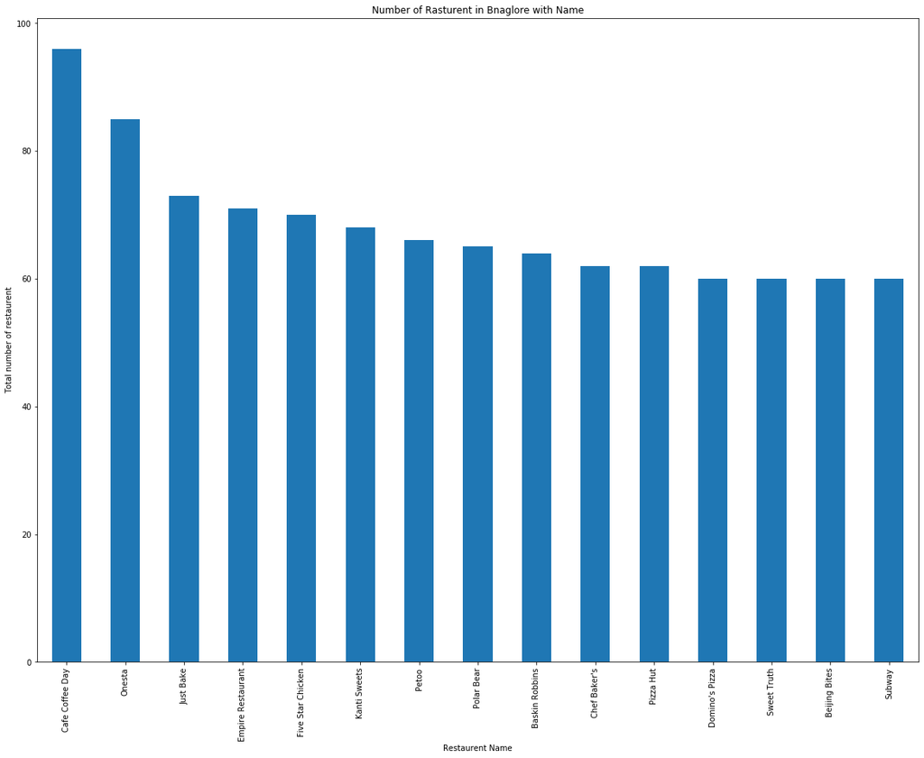

```python
plt.figure(figsize=(20,15))
df_name.plot(kind="bar")
plt.xlabel("Restaurent Name")
plt.ylabel("Total number of restaurent")
plt.title("Number of Rasturent in Bnaglore with Name")
plt.show()
```

#### Get the restaurent name with avarage cost of restaurent

```python
df_avgcost=df_Annalysis['avg_cost_of_2'].value_counts()[:10]
```

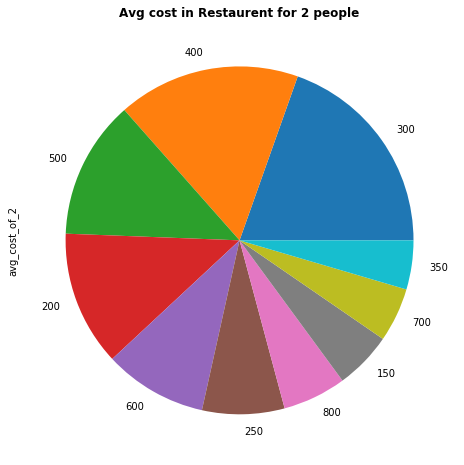

```python
plt.figure(figsize = (20,8))
df_avgcost.plot(kind = 'pie')
plt.title('Avg cost in Restaurent for 2 people', weight = 'bold')
plt.show()
```

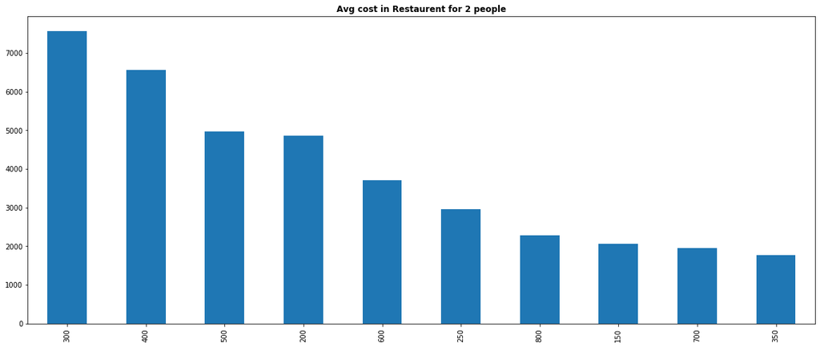

```python
plt.figure(figsize = (20,8))
df_avgcost.plot(kind = 'bar')
plt.title('Avg cost in Restaurent for 2 people', weight = 'bold')
plt.show()
```

#### Number of restaurent in each area

```python
df_city=df_Annalysis['city'].value_counts().head(15)
```

```python
df_city
```

```
BTM                      3279
Koramangala 7th Block    2938
Koramangala 5th Block    2836
Koramangala 4th Block    2779
Koramangala 6th Block    2623
Jayanagar                2371
JP Nagar                 2096
Indiranagar              1860
Church Street            1827
MG Road                  1811
Brigade Road             1769
Lavelle Road             1744
HSR                      1741
Marathahalli             1659
Residency Road           1620
Name: city, dtype: int64
```

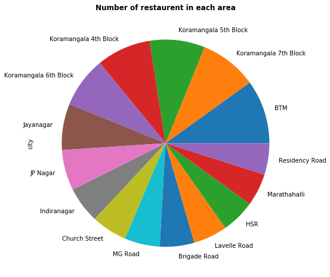

```python
plt.figure(figsize = (20,8))
df_city.plot(kind = 'pie')
plt.title('Number of restaurent in each area', weight = 'bold')
plt.show()
```

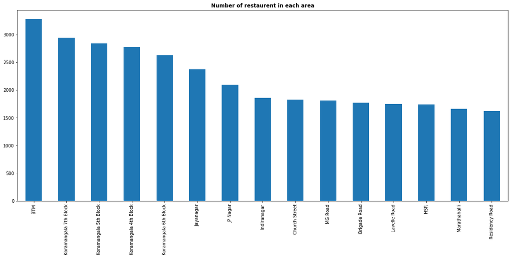

```python
plt.figure(figsize = (20,8))
df_city.plot(kind = 'bar')
plt.title('Number of restaurent in each area', weight = 'bold')
plt.show()
```

#### Restaurent accepting online order

```python
df_OnlineOrder=df_Annalysis.online_order.value_counts().head(15)
```

```python
df_OnlineOrder
```

```
1    30444
0    21273
Name: online_order, dtype: int64
```

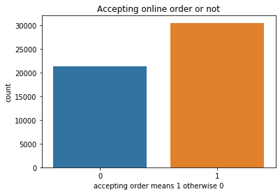

```python
sns.countplot(df_Annalysis['online_order'])
plt.xlabel("accepting order means 1 otherwise 0")
plt.title('Accepting online order or not')
plt.show()
```

#### Restaurent accepting tabel booking

```python
df_tablebooking=df_Annalysis['book_table']
```

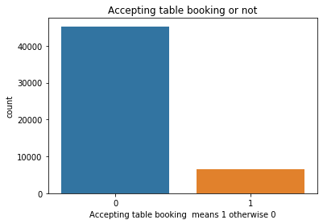

```python
sns.countplot(df_tablebooking)
plt.xlabel("Accepting table booking  means 1 otherwise 0")
plt.title('Accepting table booking or not')
plt.show()
```

## Conclusion from above

1. Maximum number of rasturent is Cafe coffee Day
2. Average cost for 2 people in maximu rasturent is 300
3. Maximum number of rasturent in city is BTM
4. Almost 30400 restaurent accepting online order
5. Maximum Rastaurent not accepting table booking

## Rating analysis we will do in NLP(Natural Language Processing)